# Data Science Statistical Inference

Ben Kooi

28-7-2021

## Synopsis

This report describes a simulation of a exponential distribution and the analysis of the TootGrowth-dataset. The questions that should be answered are:

1. Exponential Distribution Simulation
   - Show the sample mean and compare it to the theoretical mean of the distribution
   - Show how variable the sample is (via variance) and compare it to the theoretical variance of the distribution
   - Show that the distribution is approximately normal
2. Analyzing Toothgrowth Dataset
   - Provide a basic summary of the data
   - Use confidence intervals and/or hypothesis tests to compare tooth growth by supp and dose
   - Conclusions and assumptions

The sample mean, the mean of sampling the exponential distribution a 1000 times with a sampling size of 40 draws is nearly the same as theoretical mean of the exponential distribution. This also proves the Central Limit Theorem. Also the variance of the sample and the theoretical variance are nearly the same.

The most important conclusion of analyzing the ToothGrowth-dataset is that we can reject the null-hypothesis for len ~ dose, but for len ~ supp we can accept the null-hypothesis. In other words, dose matters by tootgrowth and supp not.

## Setting the environment

Load the needed packages.

```r
packages <- c("data.table","dplyr", "ggplot2")
sapply(packages, require, character.only=TRUE, quietly=TRUE)
```

```
## data.table      dplyr    ggplot2
##       TRUE       TRUE       TRUE
```

## Part 1 - Exponential Distribution Simulation

The expected value or mean of a exponential distribution is calculated by E[X]=1/λ. The standard deviation is equal to the mean and the variance is calculated by Var[X]=1/λ^2. In this case we assume that λ (=rate) is **0.2**. With this knowlegde we can calculate the theoretical mean, standard deviation and variance. These are **5**, **5** and **25**.

```r
# set the constant variables
set.seed(5)
n<-1000
samplingsize<-40
rate<-0.2

#simulate random exponential distribution
exponentialdistribution<-rexp(n,rate)

#calculate mean and variance
med<-mean(exponentialdistribution)
ved<-var(exponentialdistribution)
```

If we simulate a exponential distribution with a samplesize n=**1000** and a rate λ=**0.2**, the histogram is looks as follows:

```r
#create dataframe
ed<-data_frame(val = exponentialdistribution)
```

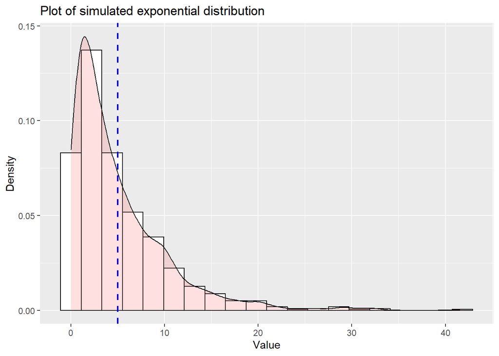

```r
#plot dataframe
plot<-ggplot(data = ed, aes(x = val)) + geom_histogram(aes(y=..density..), bins=20, colour="black", fill = "white") + geom_density(alpha=0.2, fill="#FF6666") + theme(legend.position="none") +  geom_density() +  geom_vline(xintercept = mean(ed$val), linetype="dashed", size = .75, color = "blue") +
labs(title="Plot of simulated exponential distribution", x ="Value", y = "Density")
plot
```

The summary gives the next statistics:

```r
summary(exponentialdistribution)
```

```
##     Min.  1st Qu.   Median     Mean  3rd Qu.     Max.
##  0.00678  1.45180  3.43346  5.01341  7.01110 41.83332
```

The summary shows mean = **5.0134113** and is almost equal to the theoretical mean = **5**. Also the variance = **26.094339** is almost equal to the theoretical variance = **25**.

In the next part we generate a distribution by calculating the means of samples from the exponential distribution. We take **1000** samples of with a size of **40**.

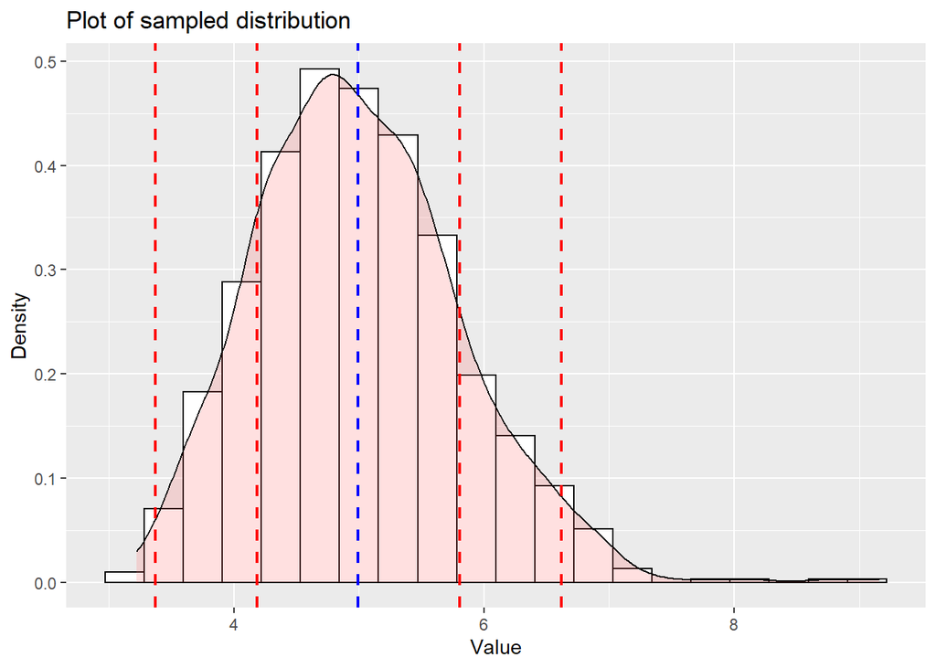

```r
#sampling from exponentialdistribution
samplemeans = NULL
for (i in 1 : 1000) samplemeans = c(samplemeans, mean(sample(exponentialdistribution, samplingsize, replace=TRUE)))
sam<-data_frame(val = samplemeans)

#calculate mean
meansam<-mean(sam$val)

#plot of distribution
plot<-ggplot(data = sam, aes(x = val)) + geom_histogram(aes(y=..density..), bins=20,colour="black", fill = "white") + geom_density(alpha=0.2, fill="#FF6666") + theme(legend.position="none") +  geom_density() +          geom_vline(xintercept = mean(sam$val), linetype="dashed", size = .75, color = "blue") +
geom_vline(xintercept = mean(sam$val)+sd(sam$val), linetype="dashed", size = .75, color = "red") +
geom_vline(xintercept = mean(sam$val)+2*sd(sam$val), linetype="dashed", size = .75, color = "red") +
geom_vline(xintercept = mean(sam$val)-sd(sam$val), linetype="dashed", size = .75, color = "red") +
geom_vline(xintercept = mean(sam$val)-2*sd(sam$val), linetype="dashed", size = .75, color = "red") +
ggtitle("Plot of sampling the exponential distribution") +
labs(title="Plot of sampled distribution", x ="Value", y = "Density")
plot
```

By plotting the distribution of the sample means, you can see that this ditribution seems to be normal. The mean of this distribution is **4.9946431**, almost the same as the mean of the exponential distribution **5.0134113**. So the Central Limit Theorem proves to be true.

## Part 2 - Analyzing Toothgrowth Dataset

The Toothgrowth Dataset contains the length of odontoblasts (cells responsible for tooth growth) in 60 guinea pigs. Each animal received one of three dose levels of vitamin C (0.5, 1, and 2 mg/day) by one of two delivery methods, OJ=orange juice or VC=ascorbic acid.

First we do a few basic analysis of the data.

```r
#change type of variable dose
ToothGrowth$dose <- as.factor(ToothGrowth$dose)

#inspect the summary and the structure of the dataset
summary(ToothGrowth)
```

```
##       len        supp     dose
##  Min.   : 4.20   OJ:30   0.5:20
##  1st Qu.:13.07   VC:30   1  :20
##  Median :19.25           2  :20
##  Mean   :18.81
##  3rd Qu.:25.27
##  Max.   :33.90
```

```r
str(ToothGrowth)
```

```
## 'data.frame':    60 obs. of  3 variables:
##  $ len : num  4.2 11.5 7.3 5.8 6.4 10 11.2 11.2 5.2 7 ...
##  $ supp: Factor w/ 2 levels "OJ","VC": 2 2 2 2 2 2 2 2 2 2 ...
##  $ dose: Factor w/ 3 levels "0.5","1","2": 1 1 1 1 1 1 1 1 1 1 ...
```

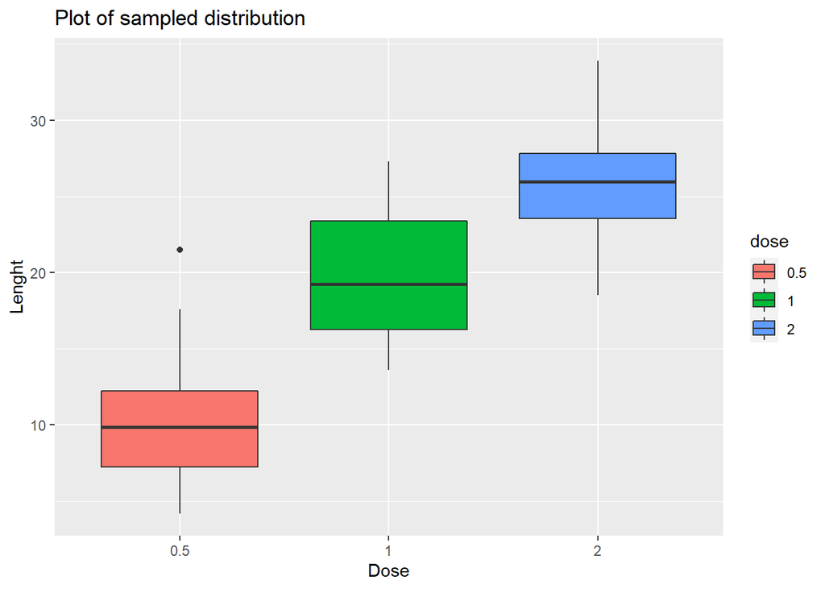

```r
# make boxplot to analyze the len ~ dose
p<-ggplot(ToothGrowth, aes(x=dose, y=len, fill=dose)) +
  geom_boxplot() +
  ggtitle("Toothgrowth per dose") +
  labs(title="Plot of sampled distribution", x ="Dose", y = "Lenght")
p
```

If we analyze the plot, it seems that len is strong dependant of dose. For proving this we perform a nopaired t.test of every combination of doses.

```r
# testing for signficance
t.test(len ~ dose, paired = FALSE, data = subset(ToothGrowth,(ToothGrowth$dose %in% c(0.5, 1))))
```

```
##
##  Welch Two Sample t-test
##
## data:  len by dose
## t = -6.4766, df = 37.986, p-value = 1.268e-07
## alternative hypothesis: true difference in means is not equal to 0
## 95 percent confidence interval:
##  -11.983781  -6.276219
## sample estimates:
## mean in group 0.5   mean in group 1
##            10.605            19.735
```

```r
t.test(len ~ dose, paired = FALSE, data = subset(ToothGrowth,(ToothGrowth$dose %in% c(0.5, 2))))
```

```
##
##  Welch Two Sample t-test
##
## data:  len by dose
## t = -11.799, df = 36.883, p-value = 4.398e-14
## alternative hypothesis: true difference in means is not equal to 0
## 95 percent confidence interval:
##  -18.15617 -12.83383
## sample estimates:
## mean in group 0.5   mean in group 2
##            10.605            26.100
```

```r
t.test(len ~ dose, paired = FALSE, data = subset(ToothGrowth,(ToothGrowth$dose %in% c(1, 2))))
```

```
##
##  Welch Two Sample t-test
##
## data:  len by dose
## t = -4.9005, df = 37.101, p-value = 1.906e-05
## alternative hypothesis: true difference in means is not equal to 0
## 95 percent confidence interval:
##  -8.996481 -3.733519
## sample estimates:
## mean in group 1 mean in group 2
##          19.735          26.100
```

Every t.test has a outcome of a p-value<0.05. So we can reject the null-hypothesis. There is a significant difference in toothgrowth if we change the dose of vitamin C.

The next analysis is to determine if the type of supplement (supp) has a significant difference in toothgrowth. First we make a boxplot.

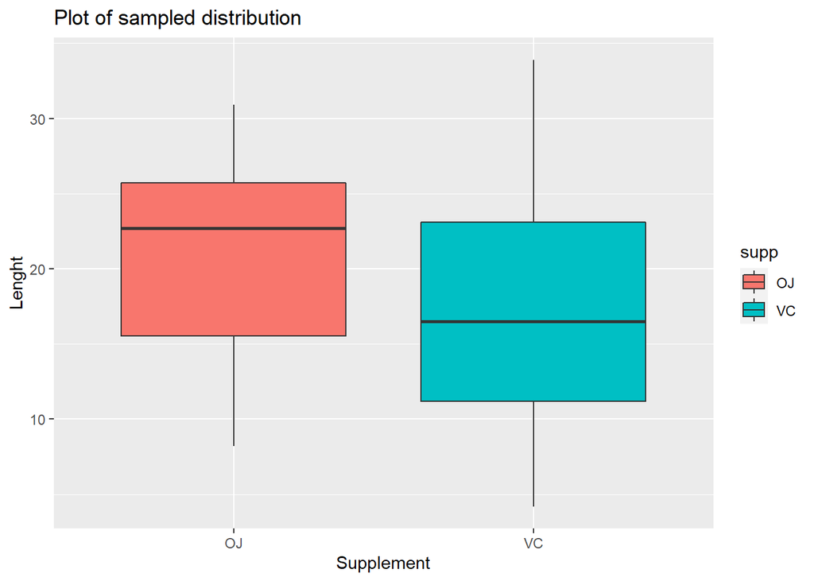

```r
#calculate mean and variance of both supplements
mvc<-mean(subset(ToothGrowth,ToothGrowth$supp=="VC")$len)
vvc<-var(subset(ToothGrowth,ToothGrowth$supp=="VC")$len)
moj<-mean(subset(ToothGrowth,ToothGrowth$supp=="OJ")$len)
voj<-var(subset(ToothGrowth,ToothGrowth$supp=="OJ")$len)

# make a boxplot len~supp
plot<-ggplot(ToothGrowth, aes(x=supp, y=len, fill=supp)) +
  geom_boxplot() +
  ggtitle("Toothgrowth per supplement") +
  labs(title="Plot of sampled distribution", x ="Supplement", y = "Lenght")
plot
```

The mean of the groups are different, so are the variance. The means are **16.9633333** vs **20.6633333** and the variances are **68.3272299** vs **43.6334368**

```r
# testing for signficance
t.test(len ~ supp, paired = FALSE, data = ToothGrowth, var.equal = FALSE)
```

```
##
##  Welch Two Sample t-test
##
## data:  len by supp
## t = 1.9153, df = 55.309, p-value = 0.06063
## alternative hypothesis: true difference in means is not equal to 0
## 95 percent confidence interval:
##  -0.1710156  7.5710156
## sample estimates:
## mean in group OJ mean in group VC
##         20.66333         16.96333
```